# Chapter 5

2023-06-03

### 5.5.2 Exercises

> 1. Currently dep_time and sched_dep_time are convenient to look at, but hard to compute with because they’re not really continuous numbers. Convert them to a more convenient representation of number of minutes since midnight.

```r
flights %>%
select(dep_time) %>%
mutate(
  dep_time_minutes = (dep_time %/% 100 * 60 + dep_time %% 100) %% 1440
)
```

```
## # A tibble: 336,776 × 2
##    dep_time dep_time_minutes
##       <int>            <dbl>
##  1      517              317
##  2      533              333
##  3      542              342
##  4      544              344
##  5      554              354
##  6      554              354
##  7      555              355
##  8      557              357
##  9      557              357
## 10      558              358
## # ℹ 336,766 more rows
```

> 2. Compare air_time with arr_time - dep_time. What do you expect to see? What do you see? What do you need to do to fix it?

[Using ‘flights’ dataset, create new columns to convert arr_time and dep_time to minutes after midnight as arr_time_minutes and dep_time_minutes and calc_air_time as the difference. select only the new columns and air_time to compare]

```r
flights %>%
  mutate(
    arr_time_minutes = (arr_time %/% 100 * 60 + arr_time %% 100) %% 1440,
    dep_time_minutes = (dep_time %/% 100 * 60 + dep_time %% 100) %% 1440,
    calc_air_time = arr_time_minutes - dep_time_minutes
  ) %>%
select(arr_time_minutes, dep_time_minutes, calc_air_time, air_time)
```

```
## # A tibble: 336,776 × 4
##    arr_time_minutes dep_time_minutes calc_air_time air_time
##               <dbl>            <dbl>         <dbl>    <dbl>
##  1              510              317           193      227
##  2              530              333           197      227
##  3              563              342           221      160
##  4              604              344           260      183
##  5              492              354           138      116
##  6              460              354           106      150
##  7              553              355           198      158
##  8              429              357            72       53
##  9              518              357           161      140
## 10              473              358           115      138
## # ℹ 336,766 more rows
```

> 3. Compare dep_time, sched_dep_time, and dep_delay. How would you expect those three numbers to be related?

[Use ‘flights’ dataset. Create new variables ‘dep_time_minutes’ and ‘sched_dep_time_minutes’ which represent minutes since midnight, ‘calc_dep_delay’ and a ‘diff’ showing difference of ‘calc_dep_delay’ and ‘dep_delay’. Select only the pertinent columns, then sort with largest differences at the top.]

```r
flights %>%
  mutate(
    dep_time_minutes = (dep_time %/% 100 * 60 + dep_time %% 100) %% 1440,
    sched_dep_time_minutes = (sched_dep_time %/% 100 * 60 + sched_dep_time %% 100) %% 1440,
    calc_dep_delay = dep_time_minutes - sched_dep_time_minutes,
    diff = calc_dep_delay - dep_delay
  ) %>% select(dep_time_minutes, sched_dep_time_minutes, calc_dep_delay, diff) %>% arrange(desc(diff))
```

```
## # A tibble: 336,776 × 4
##    dep_time_minutes sched_dep_time_minutes calc_dep_delay  diff
##               <dbl>                  <dbl>          <dbl> <dbl>
##  1              317                    315              2     0
##  2              333                    329              4     0
##  3              342                    340              2     0
##  4              344                    345             -1     0
##  5              354                    360             -6     0
##  6              354                    358             -4     0
##  7              355                    360             -5     0
##  8              357                    360             -3     0
##  9              357                    360             -3     0
## 10              358                    360             -2     0
## # ℹ 336,766 more rows
```

> 4. Find the 10 most delayed flights using 3 ranking functions [min_rank, row_number, dense_rank].

[Use ‘flights’ dataset; select the year, month, day, flight, tailnum, origin, dest, and dep_delay create 3 ‘dep_delay’ rank columns, show only those less than 10, sorted by min_rank]

```r
flights %>%
  select(year, month, day, flight, tailnum, origin, dest, dep_delay) %>%
  mutate(dep_delay_min_rank = min_rank(desc(dep_delay)),
         dep_delay_row_number = row_number(desc(dep_delay)),
         dep_delay_dense_rank = dense_rank(desc(dep_delay))) %>%
  filter(!(dep_delay_min_rank > 10 | dep_delay_row_number > 10 | dep_delay_dense_rank > 10)) %>%
  arrange(dep_delay_min_rank)
```

```
## # A tibble: 10 × 11
##     year month   day flight tailnum origin dest  dep_delay dep_delay_min_rank
##    <int> <int> <int>  <int> <chr>   <chr>  <chr>     <dbl>              <int>
##  1  2013     1     9     51 N384HA  JFK    HNL        1301                  1
##  2  2013     6    15   3535 N504MQ  JFK    CMH        1137                  2
##  3  2013     1    10   3695 N517MQ  EWR    ORD        1126                  3
##  4  2013     9    20    177 N338AA  JFK    SFO        1014                  4
##  5  2013     7    22   3075 N665MQ  JFK    CVG        1005                  5
##  6  2013     4    10   2391 N959DL  JFK    TPA         960                  6
##  7  2013     3    17   2119 N927DA  LGA    MSP         911                  7
##  8  2013     6    27   2007 N3762Y  JFK    PDX         899                  8
##  9  2013     7    22   2047 N6716C  LGA    ATL         898                  9
## 10  2013    12     5    172 N5DMAA  EWR    MIA         896                 10
## # ℹ 2 more variables: dep_delay_row_number <int>, dep_delay_dense_rank <int>
```

> 4. How are the functions min_rank() and dense_rank() different?

They both assigned the same value to “ties”; however they differ in how they handle the subsequent row. min_rank() will have gaps as it assigns the next (non-tied) row the minimum integer value place greater than the number of values less that it (ex. 1, 2, 2, 2, 5) dense_rank() will not have gaps as it assigns the next (non-tied) row the subsequent integer after the the tied ranking (ex. 1, 2, 2, 2, 3)

> 5. What does 1:3 + 1:10 return? Why?

It returns a warning “…longer object length is not a multiple of shorter object length”. When vectors are combined in R if they are different length r “recycles” the smaller to match the length of the longer. However, if the multiple of the smaller does not match that of the longer a warning message is displayed.

> 6. What are the base trigonometric functions that R provide?
- cos(x) or cospi(x)
- sin(x) or sinpi(x)
- tan(x) or tanpi(x)

> 6b. Using cosine of $\frac{\pi}{6}$ show the two types are the same.

```r
identical(cos(pi/6), cospi(1/6))
```

```
## [1] TRUE
```

## 5.6 Grouped Summaries with summarise()

What is the mean departure delay?

[Use ‘flights’ dataset; use the summarise function and remove NAs]

```r
summarise(flights, delay = mean(dep_delay, na.rm = TRUE))
```

```
## # A tibble: 1 × 1
##   delay
##   <dbl>
## 1  12.6
```

What is the mean departure delay by day?

[Use ‘flights’ dataset; Use summarise function, remove NAs]

```r
group_by(flights, year, month, day) %>%
  summarise(delay = mean(dep_delay, na.rm = TRUE))
```

```
## # A tibble: 365 × 4
## # Groups:   year, month [12]
##     year month   day delay
##    <int> <int> <int> <dbl>
##  1  2013     1     1 11.5
##  2  2013     1     2 13.9
##  3  2013     1     3 11.0
##  4  2013     1     4  8.95
##  5  2013     1     5  5.73
##  6  2013     1     6  7.15
##  7  2013     1     7  5.42
##  8  2013     1     8  2.55
##  9  2013     1     9  2.28
## 10  2013     1    10  2.84
## # ℹ 355 more rows
```

Create a new data frame called ‘delay’ with the following analysis:

1. Group flights by destination
2. Summarise to compute average distance, average delay, and number of flights.
3. Filter to remove noise (include only the destinations with more than 20 flights) and remove Honolulu airport, which is almost twice as far away as the next closest airport.

Use ‘flights’ dataset:

```r
delay <- flights %>%
  group_by(dest) %>%
  summarise(dist = mean(distance, na.rm = TRUE),
            delay = mean(arr_delay, na.rm = TRUE),
            count = n(),) %>%
  filter(count > 20, dest != "HNL")
```

Plot delay vs. dist as a scatter with the size of the point based on count. Make it transparent (alpha = 1/3). Add a smoothed curve without the standard error.

Use the ‘delay’ dataset (previously created with the ‘flights’ dataset):

[figure not shown]

```r
not_cancelled <- flights %>%
  filter(!is.na(dep_delay), !is.na(arr_delay))

not_cancelled %>%
  group_by(year, month, day) %>%
  summarise(mean = mean(dep_delay), .groups = "drop_last")
```

```
## # A tibble: 365 × 4
## # Groups:   year, month [12]
##     year month   day  mean
##    <int> <int> <int> <dbl>
##  1  2013     1     1 11.4
##  2  2013     1     2 13.7
##  3  2013     1     3 10.9
##  4  2013     1     4  8.97
##  5  2013     1     5  5.73
##  6  2013     1     6  7.15
##  7  2013     1     7  5.42
##  8  2013     1     8  2.56
##  9  2013     1     9  2.30
## 10  2013     1    10  2.84
## # ℹ 355 more rows
```

There is a subset of the ‘flights’ data set called ‘not_cancelled’.

[For context, it has filtered out any cancelled flights by using null values in ‘dep_delay’ and ‘arr_delay’ as proxies for cancelled flight]

Find out information about delays by tailnum by summarizing by tailnum and taking the mean of the arrival delay.

```r
delays <- not_cancelled %>%
  group_by(tailnum) %>%
  summarise(
    delay = mean(arr_delay)
  )

delays
```

```
## # A tibble: 4,037 × 2
##    tailnum  delay
##    <chr>    <dbl>
##  1 D942DN  31.5
##  2 N0EGMQ   9.98
##  3 N10156  12.7
##  4 N102UW   2.94
##  5 N103US  -6.93
##  6 N104UW   1.80
##  7 N10575  20.7
##  8 N105UW  -0.267
##  9 N107US  -5.73
## 10 N108UW  -1.25
## # ℹ 4,027 more rows
```

The ‘delays’ dataset has a the average arrival delay by tailnum. Use the dataset to create a frequency polygon for the average delay with a binwidth of 10.

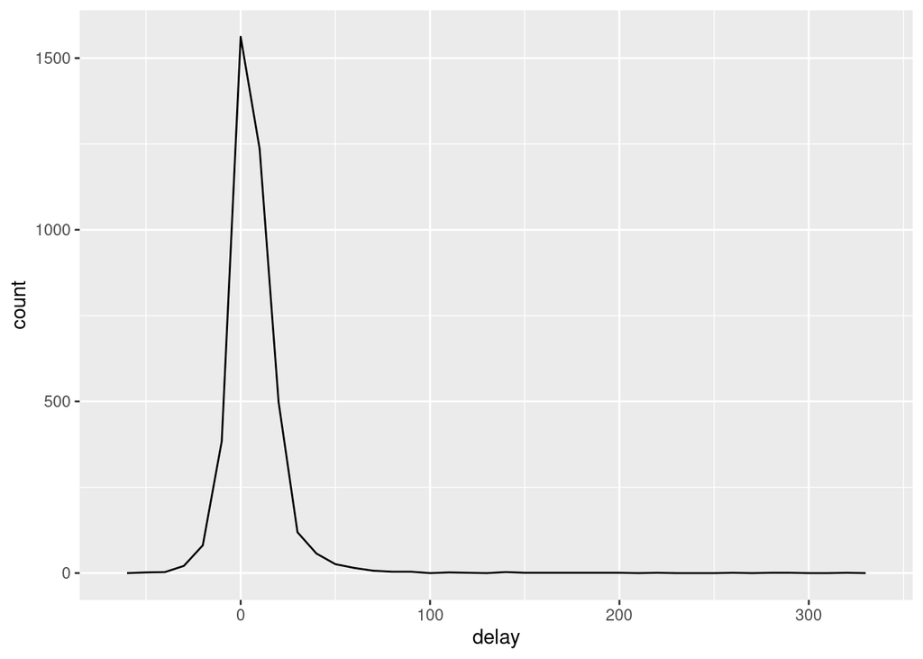

```r
ggplot(data = delays, mapping = aes(x = delay)) +
  geom_freqpoly(binwidth = 10)
```

The ‘delay’ dataset shows us that some planes have an average delay of 300 minutes! Let’s recreate it (from the not_cancelled dataset) and remove nulls from the average as well as creating the count of flights.

```r
delays <- not_cancelled %>%
  group_by(tailnum) %>%
  summarise(
    delay = mean(arr_delay, na.rm = TRUE),
    n = n()
  )
```

Now create a scatter plot of the information. Delay by count (n). [Given the number of points let’s set alpha to 1/10]

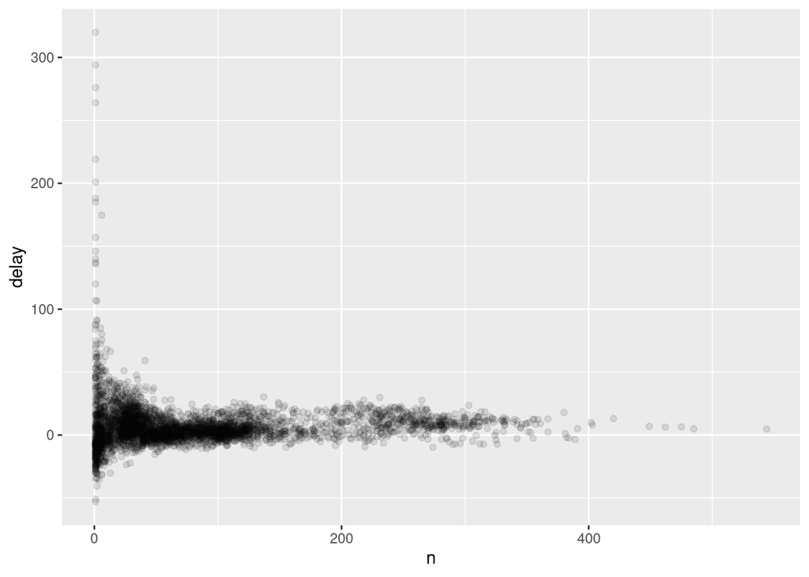

```r
ggplot(data = delays, mapping = aes(x = n, y = delay)) +
  geom_point(alpha = 1/10)
```

Let’s plot the information again, but let’s only look at airplanes that had more than 25 flights. [Essentially removing the planes with few flights]

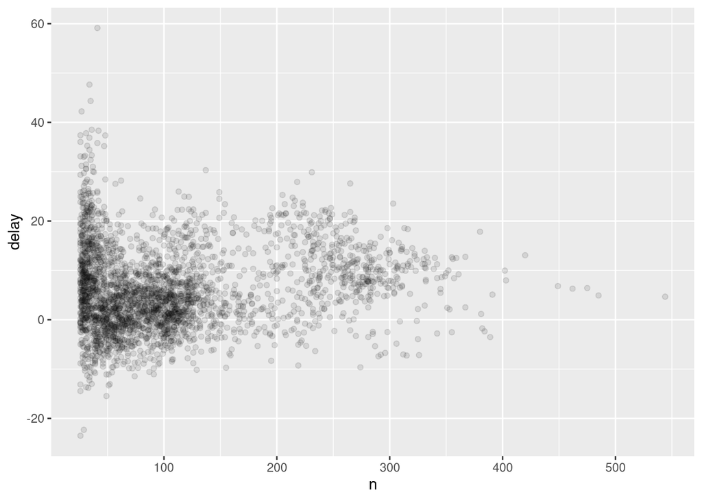

```r
delays %>%
  filter(n > 25) %>%
  ggplot(mapping = aes(x = n, y = delay)) +
  geom_point(alpha = 1/10)
```

```r
library(Lahman)
batting <- as_tibble(Lahman::Batting)
```

With the ‘batting’ dataset create a batting average column ‘ba’ (Hits ‘H’ / At Bats ‘AB’) and the At Bats ‘ab’ column removing “na”s all by PlayerID

```r
batters <- batting %>%
  group_by(playerID) %>%
  summarise(
    ba = sum(H, na.rm = TRUE) / sum(AB, na.rm = TRUE),
    ab = sum(AB, na.rm = TRUE)
    )
```

Using the ‘batters’ dataset plot a scatter plot of batting average ‘ba’ vs. at bats ‘ab’ for players with more than 100 at bats. Also, add a smoothed line showing the relationship (no need to add standard error)

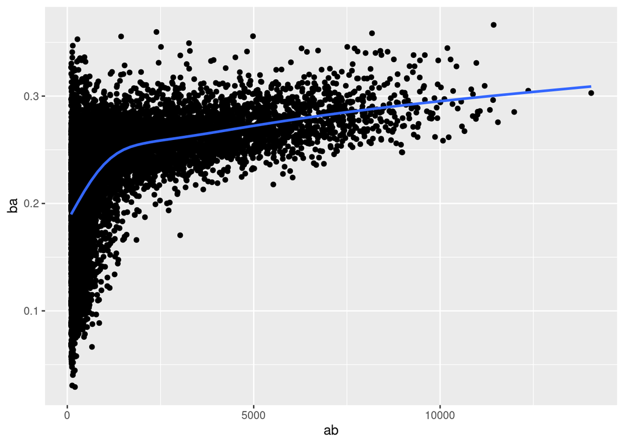

```r
batters %>%
  filter(ab > 100) %>%
  ggplot(mapping = aes(x = ab, y = ba)) +
    geom_point() +
    geom_smooth(se = FALSE)
```

GAM = Generalized Additive Model

Using the non_cancelled flights (just the subset of flights that hasn’t been cancelled) get the average arrival delay by day as well as the average positive delay

```r
not_cancelled %>%
  group_by(year, month, day) %>%
  summarise(
    avg_delay1 = mean(arr_delay),
    avg_delay2 = mean(arr_delay[arr_delay > 0]),
    .groups = "drop_last"
  )
```

```
## # A tibble: 365 × 5
## # Groups:   year, month [12]
##     year month   day avg_delay1 avg_delay2
##    <int> <int> <int>      <dbl>      <dbl>
##  1  2013     1     1     12.7         32.5
##  2  2013     1     2     12.7         32.0
##  3  2013     1     3      5.73        27.7
##  4  2013     1     4     -1.93        28.3
##  5  2013     1     5     -1.53        22.6
##  6  2013     1     6      4.24        24.4
##  7  2013     1     7     -4.95        27.8
##  8  2013     1     8     -3.23        20.8
##  9  2013     1     9     -0.264       25.6
## 10  2013     1    10     -5.90        27.3
## # ℹ 355 more rows
```

Using the ‘not_cancelled’ dataset find the standard deviation of distance by destination and sort from largest standard deviation to smallest.

```r
not_cancelled %>%
  group_by(dest) %>%
  summarise(distance_sd = sd(distance)) %>%
  arrange(desc(distance_sd))
```

```
## # A tibble: 104 × 2
##    dest  distance_sd
##    <chr>       <dbl>
##  1 EGE         10.5
##  2 SAN         10.4
##  3 SFO         10.2
##  4 HNL         10.0
##  5 SEA          9.98
##  6 LAS          9.91
##  7 PDX          9.87
##  8 PHX          9.86
##  9 LAX          9.66
## 10 IND          9.46
## # ℹ 94 more rows
```

Using ‘not_cancelled’ dataset find the first and last departure time of each day. (using min and max functions in a group/summarise)

```r
not_cancelled %>%
  group_by(year, month, day) %>%
  summarise(
    first = min(dep_time),
    last = max(dep_time),
    .groups = "drop_last"
  )
```

```
## # A tibble: 365 × 5
## # Groups:   year, month [12]
##     year month   day first  last
##    <int> <int> <int> <int> <int>
##  1  2013     1     1   517  2356
##  2  2013     1     2    42  2354
##  3  2013     1     3    32  2349
##  4  2013     1     4    25  2358
##  5  2013     1     5    14  2357
##  6  2013     1     6    16  2355
##  7  2013     1     7    49  2359
##  8  2013     1     8   454  2351
##  9  2013     1     9     2  2252
## 10  2013     1    10     3  2320
## # ℹ 355 more rows
```

Using ‘not_cancelled’ dataset find the first and last departure time of each day (using first and last functions in a group/summarise)

```r
not_cancelled %>%
  group_by(year, month, day) %>%
  summarise(
    first_dep = first(dep_time),
    last_dep = last(dep_time),
    .groups = "drop_last"
  )
```

```
## # A tibble: 365 × 5
## # Groups:   year, month [12]
##     year month   day first_dep last_dep
##    <int> <int> <int>     <int>    <int>
##  1  2013     1     1       517     2356
##  2  2013     1     2        42     2354
##  3  2013     1     3        32     2349
##  4  2013     1     4        25     2358
##  5  2013     1     5        14     2357
##  6  2013     1     6        16     2355
##  7  2013     1     7        49     2359
##  8  2013     1     8       454     2351
##  9  2013     1     9         2     2252
## 10  2013     1    10         3     2320
## # ℹ 355 more rows
```

Using ‘not_cancelled’ dataset find the first and last departure time of each day. (using group_by, mutate, filter)

```r
not_cancelled %>%
  group_by(year, month, day) %>%
  mutate(r = min_rank(desc(dep_time))) %>%
  filter(r %in% range(r))
```

```
## # A tibble: 770 × 20
## # Groups:   year, month, day [365]
##     year month   day dep_time sched_dep_time dep_delay arr_time sched_arr_time
##    <int> <int> <int>    <int>          <int>     <dbl>    <int>          <int>
##  1  2013     1     1      517            515         2      830            819
##  2  2013     1     1     2356           2359        -3      425            437
##  3  2013     1     2       42           2359        43      518            442
##  4  2013     1     2     2354           2359        -5      413            437
##  5  2013     1     3       32           2359        33      504            442
##  6  2013     1     3     2349           2359       -10      434            445
##  7  2013     1     4       25           2359        26      505            442
##  8  2013     1     4     2358           2359        -1      429            437
##  9  2013     1     4     2358           2359        -1      436            445
## 10  2013     1     5       14           2359        15      503            445
## # ℹ 760 more rows
## # ℹ 12 more variables: arr_delay <dbl>, carrier <chr>, flight <int>,
## #   tailnum <chr>, origin <chr>, dest <chr>, air_time <dbl>, distance <dbl>,
## #   hour <dbl>, minute <dbl>, time_hour <dttm>, r <int>
```

Which destinations have the most carriers?

```r
not_cancelled %>%
  group_by(dest) %>%
  summarise(carriers = n_distinct(carrier)) %>%
  arrange(desc(carriers))
```

```
## # A tibble: 104 × 2
##    dest  carriers
##    <chr>    <int>
##  1 ATL          7
##  2 BOS          7
##  3 CLT          7
##  4 ORD          7
##  5 TPA          7
##  6 AUS          6
##  7 DCA          6
##  8 DTW          6
##  9 IAD          6
## 10 MSP          6
## # ℹ 94 more rows
```

Which destinations have the most flights? (filter and sort; use the n() function)

```r
not_cancelled %>%
  group_by(dest) %>%
  summarise(n = n()) %>%
  arrange(desc(n))
```

```
## # A tibble: 104 × 2
##    dest      n
##    <chr> <int>
##  1 ATL   16837
##  2 ORD   16566
##  3 LAX   16026
##  4 BOS   15022
##  5 MCO   13967
##  6 CLT   13674
##  7 SFO   13173
##  8 FLL   11897
##  9 MIA   11593
## 10 DCA    9111
## # ℹ 94 more rows
```

Which destinations have the most flights? (filter and sort; use the count() function)

```r
not_cancelled %>%
  count(dest) %>%
  arrange(desc(n))
```

```
## # A tibble: 104 × 2
##    dest      n
##    <chr> <int>
##  1 ATL   16837
##  2 ORD   16566
##  3 LAX   16026
##  4 BOS   15022
##  5 MCO   13967
##  6 CLT   13674
##  7 SFO   13173
##  8 FLL   11897
##  9 MIA   11593
## 10 DCA    9111
## # ℹ 94 more rows
```

Find the planes that flew the most miles. (Use count() and the wt option):

```r
not_cancelled %>%
  count(tailnum, wt = distance) %>%
  arrange(desc(n))
```

```
## # A tibble: 4,037 × 2
##    tailnum      n
##    <chr>    <dbl>
##  1 N328AA  929090
##  2 N338AA  921172
##  3 N335AA  902271
##  4 N327AA  900482
##  5 N323AA  839468
##  6 N319AA  837924
##  7 N336AA  833136
##  8 N329AA  825826
##  9 N324AA  786159
## 10 N339AA  783648
## # ℹ 4,027 more rows
```

How many flights left before 5am? (Using ‘not_cancelled’ flights subset group by day and summarise)

```r
not_cancelled %>%
  group_by(year, month, day) %>%
  summarise(n_early = sum(dep_time < 500),
            .groups = "drop_last")
```

```
## # A tibble: 365 × 4
## # Groups:   year, month [12]
##     year month   day n_early
##    <int> <int> <int>   <int>
##  1  2013     1     1       0
##  2  2013     1     2       3
##  3  2013     1     3       4
##  4  2013     1     4       3
##  5  2013     1     5       3
##  6  2013     1     6       2
##  7  2013     1     7       2
##  8  2013     1     8       1
##  9  2013     1     9       3
## 10  2013     1    10       3
## # ℹ 355 more rows
```

What proportion of flights are delayed by more than an hour?

[Using ‘not_cancelled’ dataset, a ‘flights’ subset group by day and summarise]

```r
not_cancelled %>%
  group_by(year, month, day) %>%
  summarise(hour_prop = mean(arr_delay > 60),
            .groups = "drop_last")
```

```
## # A tibble: 365 × 4
## # Groups:   year, month [12]
##     year month   day hour_prop
##    <int> <int> <int>     <dbl>
##  1  2013     1     1    0.0722
##  2  2013     1     2    0.0851
##  3  2013     1     3    0.0567
##  4  2013     1     4    0.0396
##  5  2013     1     5    0.0349
##  6  2013     1     6    0.0470
##  7  2013     1     7    0.0333
##  8  2013     1     8    0.0213
##  9  2013     1     9    0.0202
## 10  2013     1    10    0.0183
## # ℹ 355 more rows
```

```r
(daily <- group_by(flights, year, month, day))
```

```
## # A tibble: 336,776 × 19
## # Groups:   year, month, day [365]
##     year month   day dep_time sched_dep_time dep_delay arr_time sched_arr_time
##    <int> <int> <int>    <int>          <int>     <dbl>    <int>          <int>
##  1  2013     1     1      517            515         2      830            819
##  2  2013     1     1      533            529         4      850            830
##  3  2013     1     1      542            540         2      923            850
##  4  2013     1     1      544            545        -1     1004           1022
##  5  2013     1     1      554            600        -6      812            837
##  6  2013     1     1      554            558        -4      740            728
##  7  2013     1     1      555            600        -5      913            854
##  8  2013     1     1      557            600        -3      709            723
##  9  2013     1     1      557            600        -3      838            846
## 10  2013     1     1      558            600        -2      753            745
## # ℹ 336,766 more rows
## # ℹ 11 more variables: arr_delay <dbl>, carrier <chr>, flight <int>,
## #   tailnum <chr>, origin <chr>, dest <chr>, air_time <dbl>, distance <dbl>,
## #   hour <dbl>, minute <dbl>, time_hour <dttm>
```

Create and show a new dataset called ‘per_day’ that is the count of flights per day using the ‘summarise’ function on the ‘daily’ dataset.

[The ‘daily’ dataset is the ‘flights’ dataset grouped by year, month, day]

```r
(per_day   <- summarise(daily, flights = n()))
```

```
## # A tibble: 365 × 4
## # Groups:   year, month [12]
##     year month   day flights
##    <int> <int> <int>   <int>
##  1  2013     1     1     842
##  2  2013     1     2     943
##  3  2013     1     3     914
##  4  2013     1     4     915
##  5  2013     1     5     720
##  6  2013     1     6     832
##  7  2013     1     7     933
##  8  2013     1     8     899
##  9  2013     1     9     902
## 10  2013     1    10     932
## # ℹ 355 more rows
```

Create and show a new dataset called ‘per_month’ that is the count of flights per month using the ‘summarise’ function on the ‘per_day’ dataset. (Note that a group is “peeled” off after doing the summarise)

[The ‘per_day’ dataset is summarized from the ‘flights’ dataset having the count of flights grouped by year, month, day]

```r
(per_month <- summarise(per_day, flights = sum(flights)))
```

```
## # A tibble: 12 × 3
## # Groups:   year [1]
##     year month flights
##    <int> <int>   <int>
##  1  2013     1   27004
##  2  2013     2   24951
##  3  2013     3   28834
##  4  2013     4   28330
##  5  2013     5   28796
##  6  2013     6   28243
##  7  2013     7   29425
##  8  2013     8   29327
##  9  2013     9   27574
## 10  2013    10   28889
## 11  2013    11   27268
## 12  2013    12   28135
```

Create and show a new dataset called ‘per_year’ that is the count of flights per year using the ‘summarise’ function on the ‘per_month’ dataset. (Note that a group is “peeled” off after doing the summarise)

[The ‘per_month’ dataset is summarized from the ‘flights’ dataset having the count of flights grouped by year, month]

```r
(per_year  <- summarise(per_month, flights = sum(flights)))
```

```
## # A tibble: 1 × 2
##    year flights
##   <int>   <int>
## 1  2013  336776
```

Show the count of all flights by changing the ‘daily’ dataset with an ‘ungroup’ function.

[Using the ‘daily’ dataset which is created from the flights dataset with grouping by year, month, day.]

```r
daily %>%
  ungroup() %>%             # no longer grouped by date
  summarise(flights = n())  # all flights
```

```
## # A tibble: 1 × 1
##   flights
##     <int>
## 1  336776
```

Come up with another approach that will give you the number of flights by destination, i.e. not_cancelled %>% count(dest), but without using count()

[Using ‘not_cancelled’ dataset, a ‘flights’ subset]

```r
not_cancelled %>%
  group_by(dest) %>%
  summarise(n = n())
```

```
## # A tibble: 104 × 2
##    dest      n
##    <chr> <int>
##  1 ABQ     254
##  2 ACK     264
##  3 ALB     418
##  4 ANC       8
##  5 ATL   16837
##  6 AUS    2411
##  7 AVL     261
##  8 BDL     412
##  9 BGR     358
## 10 BHM     269
## # ℹ 94 more rows
```

Come up with another approach that will give you the number of flights by destination, i.e. not_cancelled %>% count(dest), and use the tally() function

[Using ‘not_cancelled’ dataset, a ‘flights’ subset]

```r
not_cancelled %>%
  group_by(dest) %>%
  tally()
```

```
## # A tibble: 104 × 2
##    dest      n
##    <chr> <int>
##  1 ABQ     254
##  2 ACK     264
##  3 ALB     418
##  4 ANC       8
##  5 ATL   16837
##  6 AUS    2411
##  7 AVL     261
##  8 BDL     412
##  9 BGR     358
## 10 BHM     269
## # ℹ 94 more rows
```

Come up with another approach that will give you the miles traveled by tailnum, i.e. not_cancelled %>% count(tailnum, wt = distance), but without using count()

[Using ‘not_cancelled’ dataset, a ‘flights’ subset]

```r
not_cancelled %>%
  group_by(tailnum) %>%
  summarise(dist = sum(distance))
```

```
## # A tibble: 4,037 × 2
##    tailnum   dist
##    <chr>    <dbl>
##  1 D942DN    3418
##  2 N0EGMQ  239143
##  3 N10156  109664
##  4 N102UW   25722
##  5 N103US   24619
##  6 N104UW   24616
##  7 N10575  139903
##  8 N105UW   23618
##  9 N107US   21677
## 10 N108UW   32070
## # ℹ 4,027 more rows
```

Come up with another approach that will give you the miles traveled by tailnum, i.e. not_cancelled %>% count(tailnum, wt = distance), and use the tally function

[Using ‘not_cancelled’ dataset, a ‘flights’ subset]

```r
not_cancelled %>%
  group_by(tailnum) %>%
  tally(distance)
```

```
## # A tibble: 4,037 × 2
##    tailnum      n
##    <chr>    <dbl>
##  1 D942DN    3418
##  2 N0EGMQ  239143
##  3 N10156  109664
##  4 N102UW   25722
##  5 N103US   24619
##  6 N104UW   24616
##  7 N10575  139903
##  8 N105UW   23618
##  9 N107US   21677
## 10 N108UW   32070
## # ℹ 4,027 more rows
```

Look at the number of cancelled flights per day. Is there a pattern? Is the proportion of cancelled flights related to the average delay?

```r
cancel_per_day <- flights %>%
  mutate(cancelled = (is.na(arr_delay) | is.na(dep_delay))) %>%
  group_by(month, day) %>%
  summarise(
    NumCancelled = sum(cancelled),
    NumFlights = n(),
    AveDelay = mean(arr_delay, na.rm = TRUE),
    CancelProp = mean(cancelled)
  )
```

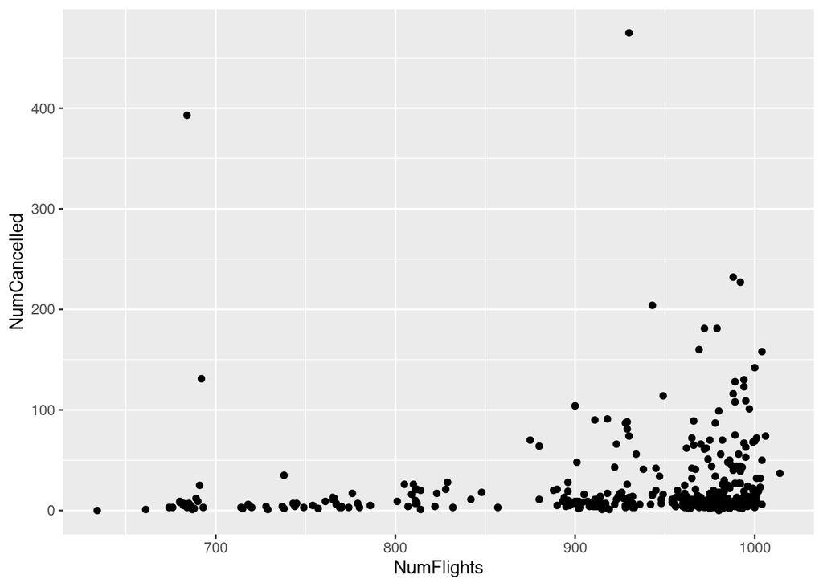

```r
ggplot(data = cancel_per_day) +
  geom_point(mapping = aes(x = NumFlights, y = NumCancelled))
```

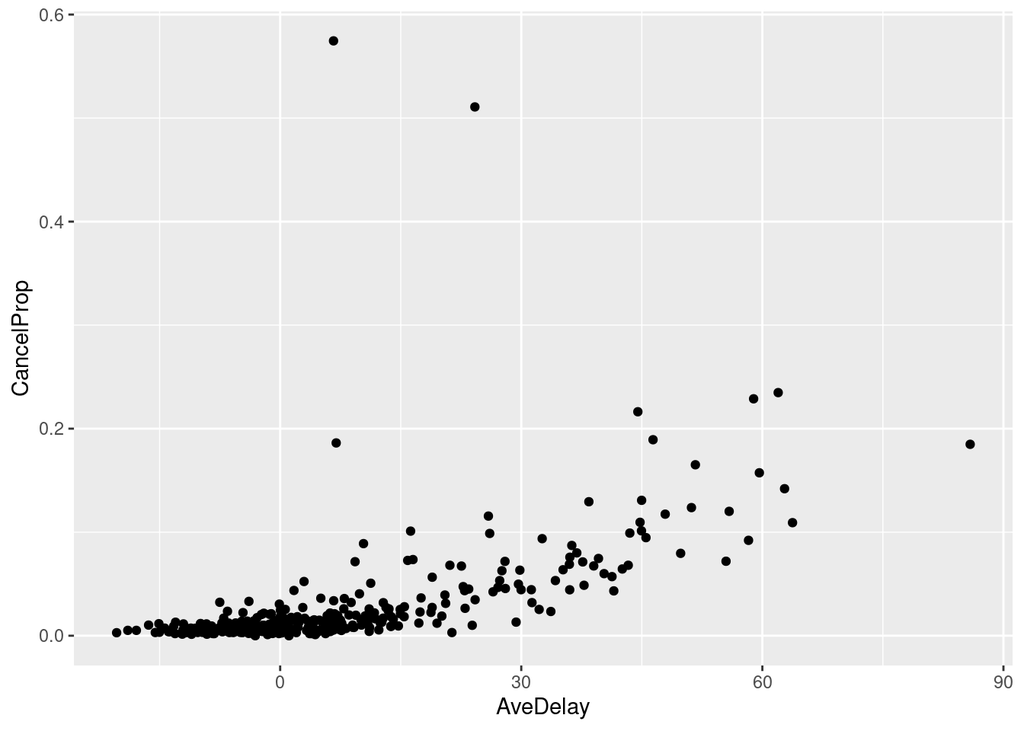

```r
ggplot(data = cancel_per_day) +
  geom_point(mapping = aes(x = AveDelay, y = CancelProp))
```

> 5A. Which carrier has the worst delays? [Use ‘not_cancelled’ dataset (a ‘flights’ subset). ]

```r
not_cancelled %>%
  mutate(Delay = (arr_delay >= 0 | dep_delay >= 0)) %>%
  group_by(carrier) %>%
  summarise(
    DelayProportion = mean(Delay),
    n = n()
  ) %>%
  arrange(desc(DelayProportion))
```

```
## # A tibble: 16 × 3
##    carrier DelayProportion     n
##    <chr>             <dbl> <int>
##  1 F9                0.744   681
##  2 FL                0.711  3175
##  3 WN                0.699 12044
##  4 UA                0.616 57782
##  5 VX                0.606  5116
##  6 EV                0.584 51108
##  7 B6                0.572 54049
##  8 YV                0.564   544
##  9 MQ                0.549 25037
## 10 9E                0.529 17294
## 11 DL                0.505 47658
## 12 AA                0.489 31947
## 13 US                0.454 19831
## 14 AS                0.450   709
## 15 HA                0.418   342
## 16 OO                0.379    29
```

```r
not_cancelled %>%
  mutate(Delay = (arr_delay >= 0 | dep_delay >= 0)) %>%
  group_by(dest) %>%
  summarise(
    DelayProportion = mean(Delay),
    n = n()) %>%
  arrange(desc(DelayProportion))
```

```
## # A tibble: 104 × 3
##    dest  DelayProportion     n
##    <chr>           <dbl> <int>
##  1 JAC             0.905    21
##  2 ANC             0.875     8
##  3 MTJ             0.857    14
##  4 CAE             0.849   106
##  5 HDN             0.786    14
##  6 EYW             0.765    17
##  7 TUL             0.731   294
##  8 OKC             0.717   315
##  9 BZN             0.714    35
## 10 MDW             0.712  4025
## # ℹ 94 more rows
```